# Gene homology Part 3

Shirin Glander

2016-12-16

[output not shown]

## Which genes have homologs in many species and which have few?

In [Part 1](https://shiring.github.io/genome/2016/12/11/homologous_genes_post) and [Part 2](https://shiring.github.io/genome/2016/12/14/homologous_genes_part2_post) I have already explored gene homology between humans and other species. But there I have only considered how many genes where shared between the species.

In this post I want to have a closer look at what these genes are that have homologs in many species, and which genes are specific to individual species.

I am starting with the same table as from last week’s post, called *homologs_table_combined*. Check back with [Part 2](https://shiring.github.io/genome/2016/12/14/homologous_genes_part2_post) for how to produce this table.

```r
head(homologs_table_combined)
```

```
##   celegans_gene_ensembl cfamiliaris_gene_ensembl
## 1                    NA                       NA
## 2                    NA                   477699
## 3                    NA                   477023
## 4                173979                   490207
## 5                179795                   607852
## 6                177055                       NA
##   dmelanogaster_gene_ensembl drerio_gene_ensembl ggallus_gene_ensembl
## 1                         NA                  NA                   NA
## 2                      44071                  NA                   NA
## 3                         NA              431754               770094
## 4                      38864              406283                   NA
## 5                      36760              794259               395373
## 6                    3772179              541489               421909
##   hsapiens_gene_ensembl mmusculus_gene_ensembl ptroglodytes_gene_ensembl
## 1                    NA                     NA                        NA
## 2                     2                 232345                    465372
## 3                    30                 235674                    460268
## 4                    34                  11364                    469356
## 5                    47                 104112                    454672
## 6                    52                  11431                    458990
##   rnorvegicus_gene_ensembl scerevisiae_gene_ensembl sscrofa_gene_ensembl
## 1                    24152                       NA                   NA
## 2                    24153                       NA               403166
## 3                    24157                   854646            100515577
## 4                    24158                       NA               397104
## 5                    24159                   854310                   NA
## 6                    24161                   856187            100737301
```

Each row in this table denotes a gene with its Entrez ID and corresponding Entrez IDs for homologs in each of the other 10 species I explored. If a gene doesn’t have homolog the table says “NA”. However, some genes have duplicate entries for a species if there are multiple homologs in different species.

By counting the number of NAs per row, we can identify genes with homologs in all species (sum of NAs = 0) and genes which are specific (sum of NAs = 10).

```r
homologs_na <- rowSums(is.na(homologs_table_combined))
```

Before I delve deeper into the biology behind these genes, I want to examine the distribution of the NA-counts. To do so, I am plotting a histogram:

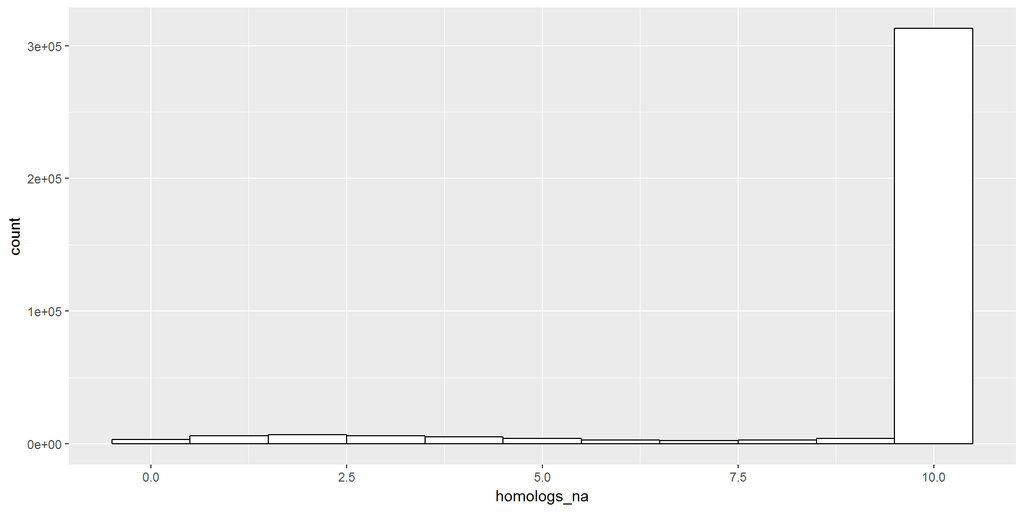

```r
library(ggplot2)
ggplot() + aes(homologs_na) + geom_histogram(binwidth = 1, colour = "black", fill = "white")
```

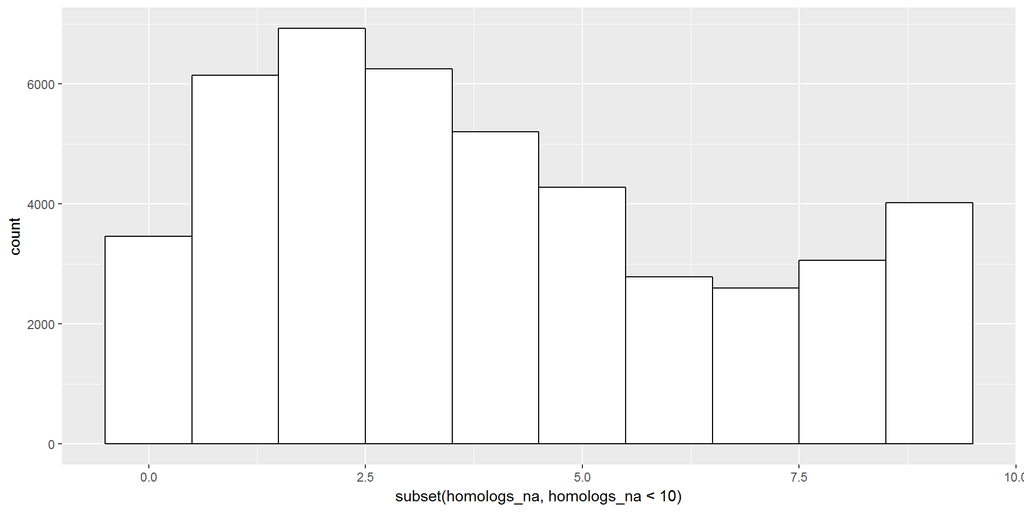

```r
ggplot() + aes(subset(homologs_na, homologs_na  < 10)) + geom_histogram(binwidth = 1, colour = "black", fill = "white")
```

Now we can see that most genes have homologs in 9 species (2 NAs). But there are still quite a few genes with homologs in all species. These I want to look at first.

### Which genes have homologs in many species?

There are 3461 rows in the original table with no NAs.

```r
genes_homologs_all <- homologs_table_combined[which(rowSums(is.na(homologs_table_combined)) == 0), ]
nrow(genes_homologs_all)
```

```
## [1] 3461
```

Looking at all of these genes by hand wouldn’t be feasible. So, to find out what biological functions these genes have, I am using gene ontology (GO-term) enrichment analysis as implemented in [clusterProfiler](https://bioconductor.org/packages/release/bioc/html/clusterProfiler.html).

```r
library(clusterProfiler)
library(DOSE)

for (i in 1:nrow(datasets)){
  species <- datasets$dataset[i]
  genes <- as.character(unique(genes_homologs_all[, species]))
  universe <- as.character(unique(na.omit(homologs_table_combined[, species])))

  cat("\nSpecies", datasets$description[i], "has", length(universe), "unique Entrez IDs, of which", length(genes), "have homologs in all species.\n")

  try(go_enrich <- enrichGO(gene = genes,
                        keytype = "ENTREZID",
                        OrgDb = get(datasets$orgDb[i]),
                        ont = "BP",
                        qvalueCutoff = 0.05,
                        universe = universe,
                        readable = TRUE))

  try(assign(paste("go_enrich", species, sep = "_"), go_enrich))
}
```

```
##
## Species Rat has 47989 unique Entrez IDs, of which 1796 have homologs in all species.
##
## Species Yeast has 6350 unique Entrez IDs, of which 1363 have homologs in all species.
##
## Species C. elegans has 46727 unique Entrez IDs, of which 1758 have homologs in all species.
##
## Species Chimpanzee has 40540 unique Entrez IDs, of which 1704 have homologs in all species.
##
## Species Pig has 54622 unique Entrez IDs, of which 1708 have homologs in all species.
##
## Species Human has 60136 unique Entrez IDs, of which 1757 have homologs in all species.
##
## Species Chicken has 34668 unique Entrez IDs, of which 1684 have homologs in all species.
##
## Species Zebrafish has 47900 unique Entrez IDs, of which 1910 have homologs in all species.
##
## Species Fruitfly has 25038 unique Entrez IDs, of which 1805 have homologs in all species.
##
## Species Mouse has 68603 unique Entrez IDs, of which 1761 have homologs in all species.
##
## Species Dog has 31376 unique Entrez IDs, of which 1716 have homologs in all species.
```

I’m not sure why yeast throws an error but since all the other species worked I will ignore the yeast gene for now…

#### Which GO terms are enriched in all species?

10 GO terms were found to be enriched in all 10 species:

```r
datasets_2 <- datasets[-grep("scerevisiae_gene_ensembl", datasets$dataset), ]
go_list <- lapply(datasets_2$dataset, function(x) NULL)
names(go_list) <- paste(datasets_2$dataset)

for (species in datasets_2$dataset){
  df <- get(paste("go_enrich", species, sep = "_"))
  go_list[[species]] <- summary(df)$ID
}

common_gos <- summary(go_enrich_cfamiliaris_gene_ensembl)

library(rlist)
common_gos[which(rownames(common_gos) %in% list.common(go_list)), 2, drop = FALSE]
```

```
##                                               Description
## GO:0022613           ribonucleoprotein complex biogenesis
## GO:0042254                            ribosome biogenesis
## GO:0006520          cellular amino acid metabolic process
## GO:0034470                               ncRNA processing
## GO:0006399                         tRNA metabolic process
## GO:0007034                             vacuolar transport
## GO:0022618             ribonucleoprotein complex assembly
## GO:0071826 ribonucleoprotein complex subunit organization
## GO:0009116                   nucleoside metabolic process
## GO:0048193                        Golgi vesicle transport
```

#### Comparing GO term enrichment between different species

```r
library(tm)
library(SnowballC)
library(wordcloud)
library(RColorBrewer)

wordcloud_function <- function(data = data,
                               removewords = c("process", "activity", "positive", "negative", "response", "regulation"),
                               min.freq = 4,
                               max.words=Inf,
                               random.order=TRUE){
  input <- Corpus(VectorSource(data))

  input <- tm_map(input, content_transformer(tolower))
  input <- tm_map(input, content_transformer(removePunctuation))
  input <- tm_map(input, removeNumbers)
  input <- tm_map(input, stripWhitespace)

  toSpace <- content_transformer(function (x , pattern ) gsub(pattern, " ", x))
  input <- tm_map(input, toSpace, "/")
  input <- tm_map(input, toSpace, "@")
  input <- tm_map(input, toSpace, "\\|")

  input <- tm_map(input, function(x) removeWords(x, stopwords("english")))

  # specify your stopwords as a character vector
  input <- tm_map(input, removeWords, removewords)

  tdm <- TermDocumentMatrix(input)
  m <- as.matrix(tdm)
  v <- sort(rowSums(m),decreasing=TRUE)
  d <- data.frame(word = names(v),freq=v)

  set.seed(1234)
  wordcloud(words = d$word, freq = d$freq, min.freq = min.freq, scale=c(8,.2),
            max.words=max.words, random.order=random.order, rot.per=0.15,
            colors=brewer.pal(8, "Dark2"))
}
```

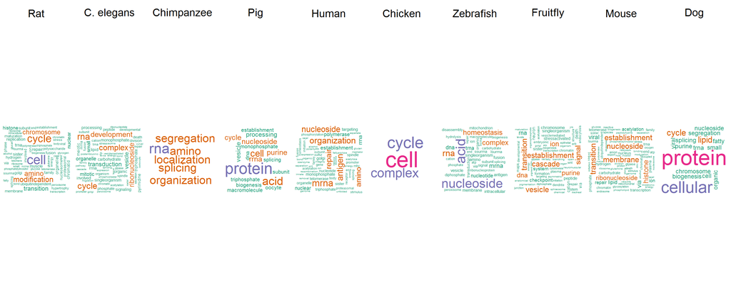

```r
layout(matrix(c(1:20), nrow = 2, byrow = FALSE), heights = c(0.1, 1))

for (i in 1:nrow(datasets_2)){
  species <- datasets_2$dataset[i]
  df <- summary(get(paste("go_enrich", species, sep = "_")))

  par(mar=rep(0, 4))
  plot.new()
  text(x=0.5, y=0.5, paste0(datasets_2$description[i]), cex = 2)
  wordcloud_function(data = df$Description)
}
```